# Group1_finalprojectRmd

###Wk1 F:B and Wk1 Butyrate

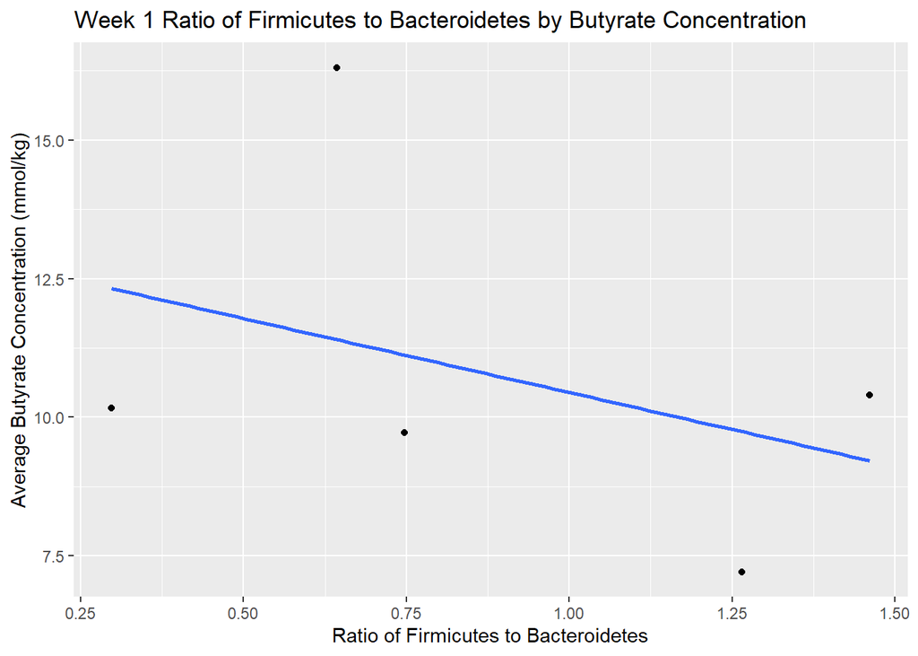

```r
#PLOT
obwk1fb_wk1but_plot<-obese_phylum_scfa %>%
  ggplot(aes(x = fb_ratio_wk1,
             y = but_wk1)) +
  geom_point() + #puts data points to match x and y coordinates
  geom_smooth(method = "lm", #used to create a linear best fit line
              se = FALSE) + #hides confidence interval around line
 labs(title = "Week 1 Ratio of Firmicutes to Bacteroidetes by Butyrate Concentration",
         x = "Ratio of Firmicutes to Bacteroidetes",
         y = "Average Butyrate Concentration (mmol/kg)")
print(obwk1fb_wk1but_plot)
```

```r
#TEST
obwk1fb_wk1but_test <- obese_phylum_scfa %>%
  lm(fb_ratio_wk1 ~ but_wk1, data = .) #test relationship
summary(obwk1fb_wk1but_test) #view results
```

```
##
## Call:
## lm(formula = fb_ratio_wk1 ~ but_wk1, data = .)
##
## Residuals:
##        1        2        3        4        5
##  0.05688 -0.19146  0.55956 -0.61765  0.19267
##
## Coefficients:
##             Estimate Std. Error t value Pr(>|t|)
## (Intercept)  1.45749    0.84471   1.725    0.183
## but_wk1     -0.05340    0.07562  -0.706    0.531
##
## Residual standard error: 0.5072 on 3 degrees of freedom
## Multiple R-squared:  0.1425, Adjusted R-squared:  -0.1433
## F-statistic: 0.4986 on 1 and 3 DF,  p-value: 0.531
```

```r
#p-value = 0.531
#Adjusted R-squared = -0.1433

#Save Plot
save_plot(filename = "figures/obwk1fb_wk1but_plot.pdf", plot = obwk1fb_wk1but_plot, nrow = 1, ncol = 1, base_aspect_ratio = 2:1)
```

The p-value for the linear correlation of the week 1 firmicutes to bacteroidetes ratio and the week 1 average butyrate concentration among “obese” participants was 0.531, which falls within a 95% confidence interval. However, the R value was an insignificant value (-0.1433). There does not appear to be a statistically significant linear relationship between the week 1 firmicutes to bacteroidetes ratio and the week 1 average butyrate concentration among participants whose BMI falls within the CDC’s “Obese” category.

###Wk1 F:B and Wk1 Propionate

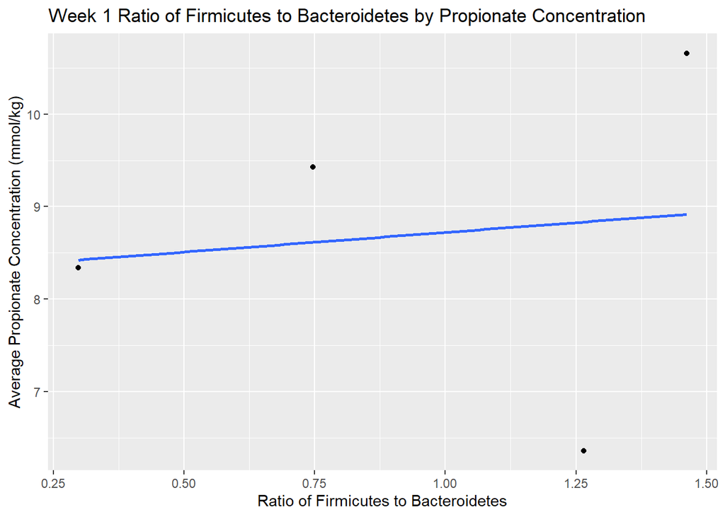

```r
#PLOT
obwk1fb_wk1pro_plot<-obese_phylum_scfa %>%
  ggplot(aes(x = fb_ratio_wk1,
             y = pro_wk1)) +
  geom_point() + #puts data points to match x and y coordinates
  geom_smooth(method = "lm", #used to create a linear best fit line
              se = FALSE) + #hides confidence interval around line
 labs(title = "Week 1 Ratio of Firmicutes to Bacteroidetes by Propionate Concentration",
         x = "Ratio of Firmicutes to Bacteroidetes",
         y = "Average Propionate Concentration (mmol/kg)")
print(obwk1fb_wk1pro_plot)
```

```r
#TEST
obwk1fb_wk1pro_test <- obese_phylum_scfa %>%
  lm(fb_ratio_wk1 ~ pro_wk1, data = .) #test relationship
summary(obwk1fb_wk1pro_test) #view results
```

```
##
## Call:
## lm(formula = fb_ratio_wk1 ~ pro_wk1, data = .)
##
## Residuals:
##       2       3       4       5
## -0.2216  0.4497 -0.6329  0.4049
##
## Coefficients:
##             Estimate Std. Error t value Pr(>|t|)
## (Intercept)  0.63585    1.78708   0.356    0.756
## pro_wk1      0.03529    0.20216   0.175    0.877
##
## Residual standard error: 0.6386 on 2 degrees of freedom
##   (1 observation deleted due to missingness)
## Multiple R-squared:  0.01501,    Adjusted R-squared:  -0.4775
## F-statistic: 0.03047 on 1 and 2 DF,  p-value: 0.8775
```

```r
#p-value = 0.8775
#Adjusted R-squared = -0.4775


#Save Plot
save_plot(filename = "figures/obwk1fb_wk1pro_plot.pdf", plot = obwk1fb_wk1pro_plot, nrow = 1, ncol = 1, base_aspect_ratio = 2:1)
```

The p-value for the linear correlation of the week 1 firmicutes to bacteroidetes ratio and the week 1 average propionate concentration among “obese” participants was 0.8775, which falls within a 95% confidence interval. However, the R value was an insignificant value (-0.4775). There does not appear to be a statistically significant linear relationship between the week 1 firmicutes to bacteroidetes ratio and the week 1 average propionate concentration among participants whose BMI falls within the CDC’s “Obese” category.

###Wk3 F:B and Wk3 Butyrate

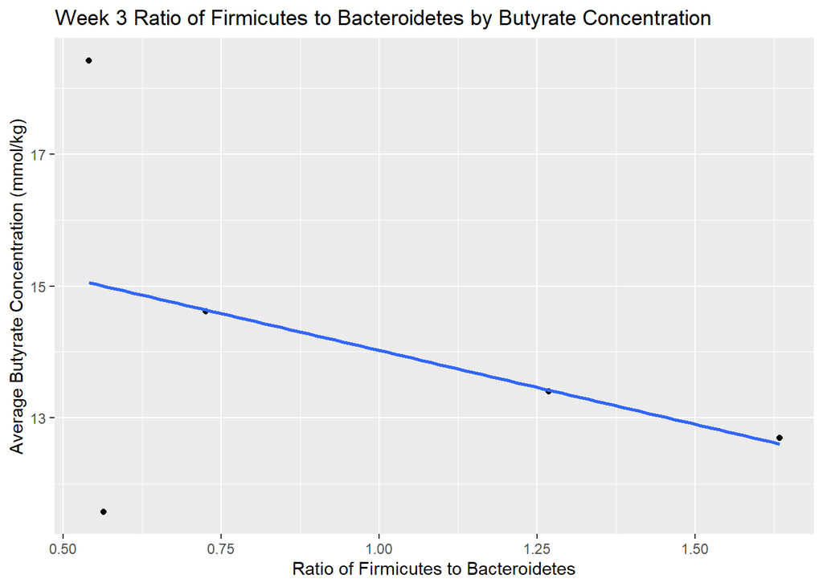

```r
#PLOT
obwk3fb_wk3but_plot<-obese_phylum_scfa %>%
  ggplot(aes(x = fb_ratio_wk3,
             y = but_wk3)) +
  geom_point() + #puts data points to match x and y coordinates
  geom_smooth(method = "lm", #used to create a linear best fit line
              se = FALSE) + #hides confidence interval around line
 labs(title = "Week 3 Ratio of Firmicutes to Bacteroidetes by Butyrate Concentration",
         x = "Ratio of Firmicutes to Bacteroidetes",
         y = "Average Butyrate Concentration (mmol/kg)")
print(obwk3fb_wk3but_plot)
```

```r
#TEST
obwk3fb_wk3but_test <- obese_phylum_scfa %>%
  lm(fb_ratio_wk3 ~ but_wk3, data = .) #test relationship
summary(obwk3fb_wk3but_test) #view results
```

```
##
## Call:
## lm(formula = fb_ratio_wk3 ~ but_wk3, data = .)
##
## Residuals:
##        1        2        3        4        5
## -0.18497 -0.08322  0.26603 -0.57585  0.57801
##
## Coefficients:
##             Estimate Std. Error t value Pr(>|t|)
## (Intercept)  2.01291    1.38645   1.452    0.242
## but_wk3     -0.07541    0.09669  -0.780    0.492
##
## Residual standard error: 0.5091 on 3 degrees of freedom
## Multiple R-squared:  0.1686, Adjusted R-squared:  -0.1086
## F-statistic: 0.6082 on 1 and 3 DF,  p-value: 0.4923
```

```r
#p-value = 0.4923
#Adjusted R-squared = -0.1086

#Save Plot
save_plot(filename = "figures/obwk3fb_wk3but_plot.pdf", plot = obwk3fb_wk3but_plot, nrow = 1, ncol = 1, base_aspect_ratio = 2:1)
```

The p-value for the linear correlation of the week 3 firmicutes to bacteroidetes ratio and the week 3 average butyrate concentration among “obese” participants was 0.4923, which is not statistically significant. Furthermore, the R value was an insignificant value close to zero (-0.1086). There does not appear to be a statistically significant linear relationship between the week 3 firmicutes to bacteroidetes ratio and the week 3 average butyrate concentration among participants whose BMI falls within the CDC’s “Obese” category.

###Wk3 F:B and Wk3 Propionate

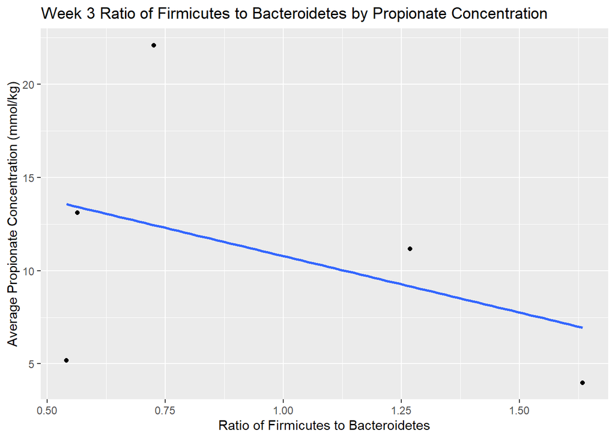

```r
#PLOT
obwk3fb_wk3pro_plot<-obese_phylum_scfa %>%
  ggplot(aes(x = fb_ratio_wk3,
             y = pro_wk3)) +
  geom_point() + #puts data points to match x and y coordinates
  geom_smooth(method = "lm", #used to create a linear best fit line
              se = FALSE) + #hides confidence interval around line
 labs(title = "Week 3 Ratio of Firmicutes to Bacteroidetes by Propionate Concentration",
         x = "Ratio of Firmicutes to Bacteroidetes",
         y = "Average Propionate Concentration (mmol/kg)")
print(obwk3fb_wk3pro_plot)
```

```r
#TEST
obwk3fb_wk3pro_test <- obese_phylum_scfa %>%
  lm(fb_ratio_wk3 ~ pro_wk3, data = .) #test relationship
summary(obwk3fb_wk3pro_test) #view results
```

```
##
## Call:
## lm(formula = fb_ratio_wk3 ~ pro_wk3, data = .)
##
## Residuals:
##        1        2        3        4        5
##  0.07465 -0.56512  0.32348 -0.32846  0.49544
##
## Coefficients:
##             Estimate Std. Error t value Pr(>|t|)
## (Intercept)  1.24509    0.45287   2.749   0.0708 .
## pro_wk3     -0.02689    0.03520  -0.764   0.5005
## ---
## Signif. codes:  0 '***' 0.001 '**' 0.01 '*' 0.05 '.' 0.1 ' ' 1
##
## Residual standard error: 0.5109 on 3 degrees of freedom
## Multiple R-squared:  0.1629, Adjusted R-squared:  -0.1162
## F-statistic: 0.5837 on 1 and 3 DF,  p-value: 0.5005
```

```r
#p-value = 0.5005
#Adjusted R-squared = -0.1162

#Save Plot
save_plot(filename = "figures/obwk3fb_wk3pro_plot.pdf", plot = obwk3fb_wk3pro_plot, nrow = 1, ncol = 1, base_aspect_ratio = 2:1)
```

The p-value for the linear correlation of the week 3 firmicutes to bacteroidetes ratio and the week 3 average propionate concentration among “obese” participants was 0.5005, which falls within a 95% confidence interval. However, the R value was an insignificant value close to zero (-0.1162). There does not appear to be a statistically significant linear relationship between the week 3 firmicutes to bacteroidetes ratio and the week 3 average propionate concentration among participants whose BMI falls within the CDC’s “Obese” category.

#Supplemental: Pre-Work This analysis was completed prior to analyzing BMI data and was not presented in our final presentation. These tests investigate potential relationships between butyrate and propionate and were eventaully subsetted by specific supplements. We also tried subsetting for only when butyrate increased and only when propionate decreased. We hypothesized that an increase in butyrate would be correlated with a decrease in propionate. #Broad ### Tidy Data #### Week 1 - Week 3 Change All

```r
but_wide <- all_data_wkly %>%
  rename_all(tolower) %>%
  select(participant_id, semester, supplement_consumed, frequency, quantity_compliant, study_week, butyrate_mean) %>% #keep only columns of interest
  filter(study_week == "week1" | study_week == "week3", quantity_compliant == "yes") %>% #keep only weeks of interest, quantity compliant, and 1x
  spread(study_week, butyrate_mean) %>%
  mutate(delta_butyrate = week1 - week3) #calculate difference in butyrate

pro_wide <- all_data_wkly %>%
  rename_all(tolower) %>%
  select(participant_id, semester, supplement_consumed, frequency, quantity_compliant, study_week, propionate_mean) %>% #keep only columns of interest
  filter(study_week == "week1" | study_week == "week3", quantity_compliant == "yes") %>% #keep only weeks of interest, quantity compliant, and 1x
  spread(study_week, propionate_mean) %>%
  mutate(delta_propionate = week1 - week3) #calculate difference in propionate

delta_but_pro_wide <- inner_join(x = but_wide, y = pro_wide,
                    by = c("participant_id",
                           "semester", "supplement_consumed", "frequency")) %>%
  select(-starts_with("week"), -starts_with("quantity_compliant"))


incbut_broad_delta_wide <- delta_but_pro_wide %>%
  filter(delta_butyrate > 0) #subset for only increased burtyrate

decpro_broad_delta_wide <- delta_but_pro_wide %>%
  filter(delta_propionate < 0) #subset for only increased burtyrate
```

###Analysis ####Plot

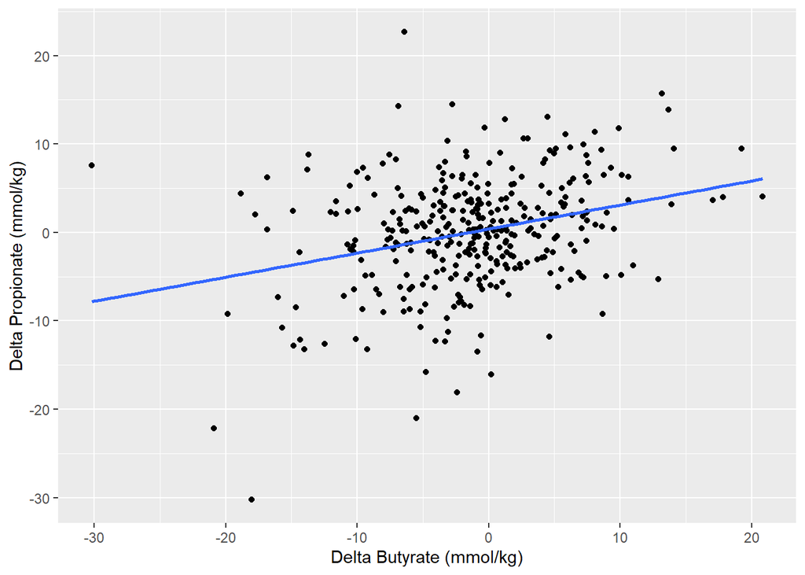

```r
linear_correlation_plot<-delta_but_pro_wide %>%
  ggplot(aes(x = delta_butyrate,
             y = delta_propionate)) +
  geom_point() + #puts data points to match x and y coordinates
  geom_smooth(method = "lm", #used to create a linear best fit line
              se = FALSE) + #hides confidence interval around line
  xlab("Delta Butyrate (mmol/kg)") +
  ylab("Delta Propionate (mmol/kg)")
print(linear_correlation_plot)
```

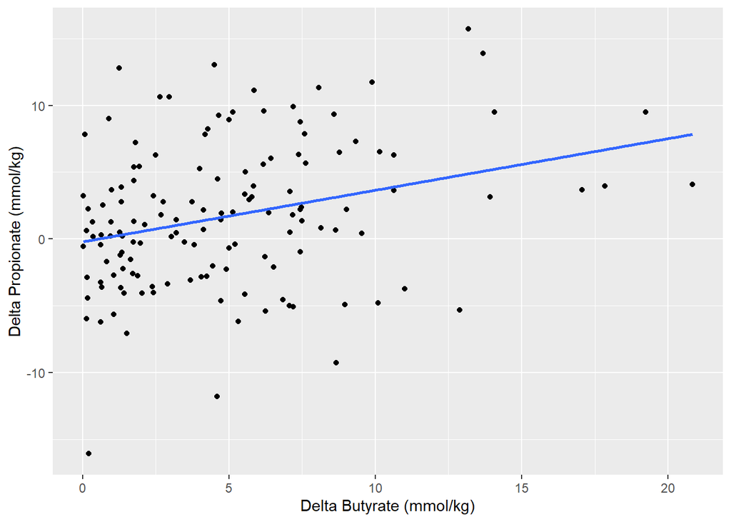

```r
incbut_broad_plot<-incbut_broad_delta_wide %>%
  ggplot(aes(x = delta_butyrate,
             y = delta_propionate)) +
  geom_point() + #puts data points to match x and y coordinates
  geom_smooth(method = "lm", #used to create a linear best fit line
              se = FALSE) + #hides confidence interval around line
  xlab("Delta Butyrate (mmol/kg)") +
  ylab("Delta Propionate (mmol/kg)")
print(incbut_broad_plot)
```

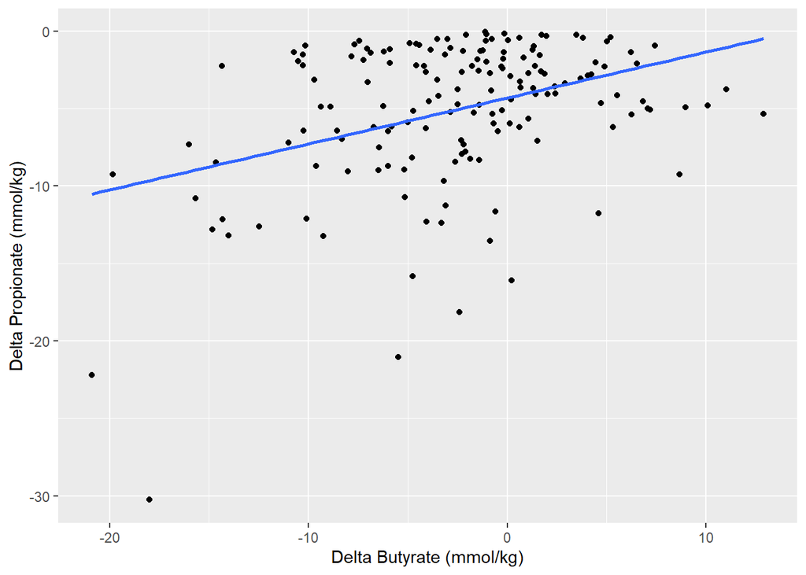

```r
decpro_broad_plot<-decpro_broad_delta_wide %>%
  ggplot(aes(x = delta_butyrate,
             y = delta_propionate)) +
  geom_point() + #puts data points to match x and y coordinates
  geom_smooth(method = "lm", #used to create a linear best fit line
              se = FALSE) + #hides confidence interval around line
  xlab("Delta Butyrate (mmol/kg)") +
  ylab("Delta Propionate (mmol/kg)")
print(decpro_broad_plot)
```

####Assumptions

```r
nrow(delta_but_pro_wide) # sample size
```

```
## [1] 481
```